# El efecto de la persepcion de la meritocracia sobre la aceptacion de la desigualdad de oportunidades

# 7 Incorporando actitud hacia la igualdad y preferencias redistributivas

```r
#se excluye egal4 por crossloading
#se excluye egal 3 7 8 por que relacionan menos

model_7<- '
f.per_mer =~ perc_recom_esfuerzo + perc_recom_talento
f.norm_desop =~ norm_sal.adel_padr.ric + norm_sal.adel_bue.cont
f.egal=~ egal_1 + egal_2 + egal_5 + egal_6

f.per_mer ~ t_des
f.norm_desop ~ a*f.per_mer
f.egal ~ b*f.norm_desop
ind_mer_egal:= a*b


'


fit_7<- sem(model_7, data=pob_recb, ordered =c("perc_recom_esfuerzo", "perc_recom_talento", "norm_sal.adel_padr.ric", "norm_sal.adel_bue.cont", "egal_1", "egal_2",  "egal_4", "egal_5", "egal_6"))

summary(fit_7, fit.measures=T, standardized=T )
```

```
## lavaan 0.6-5 ended normally after 37 iterations
##
##   Estimator                                       DWLS
##   Optimization method                           NLMINB
##   Number of free parameters                         43
##
##   Number of observations                           859
##
## Model Test User Model:
##                                               Standard      Robust
##   Test Statistic                                22.236      29.932
##   Degrees of freedom                                25          25
##   P-value (Chi-square)                           0.622       0.227
##   Scaling correction factor                                  0.920
##   Shift parameter                                            5.775
##     for the simple second-order correction
##
## Model Test Baseline Model:
##
##   Test statistic                              5062.459    3469.627
##   Degrees of freedom                                28          28
##   P-value                                        0.000       0.000
##   Scaling correction factor                                  1.463
##
## User Model versus Baseline Model:
##
##   Comparative Fit Index (CFI)                    1.000       0.999
##   Tucker-Lewis Index (TLI)                       1.001       0.998
##
##   Robust Comparative Fit Index (CFI)                            NA
##   Robust Tucker-Lewis Index (TLI)                               NA
##
## Root Mean Square Error of Approximation:
##
##   RMSEA                                          0.000       0.015
##   90 Percent confidence interval - lower         0.000       0.000
##   90 Percent confidence interval - upper         0.024       0.033
##   P-value RMSEA <= 0.05                          1.000       1.000
##
##   Robust RMSEA                                                  NA
```

[output cut: 98 more lines]

```
##
## Scales y*:
##                    Estimate  Std.Err  z-value  P(>|z|)   Std.lv  Std.all
##     perc_recm_sfrz    1.000                               1.000    1.000
##     perc_recm_tlnt    1.000                               1.000    1.000
##     nrm_sl.dl_pdr.    1.000                               1.000    1.000
##     nrm_sl.dl_b.cn    1.000                               1.000    1.000
##     egal_1            1.000                               1.000    1.000
##     egal_2            1.000                               1.000    1.000
##     egal_5            1.000                               1.000    1.000
##     egal_6            1.000                               1.000    1.000
##
## Defined Parameters:
##                    Estimate  Std.Err  z-value  P(>|z|)   Std.lv  Std.all
##     ind_mer_egal     -0.116    0.026   -4.480    0.000   -0.113   -0.113
```

```r
semPaths(fit_7 ,
what="std",
label.cex=1,
edge.label.cex=1,
residuals=F,
edge.color = "Black",
thresholds= F,#Esto saca las lineas dentro de los cuadrados que representan las variables.
intercepts = F, shapeInt = "Null", structural = F, freeStyle = 1, pastel =F,  layoutSplit = T, rainbowStart = 0, exoCov = F, color = "white", panelGroups = T, subRes = 4, covAtResiduals = F )
```

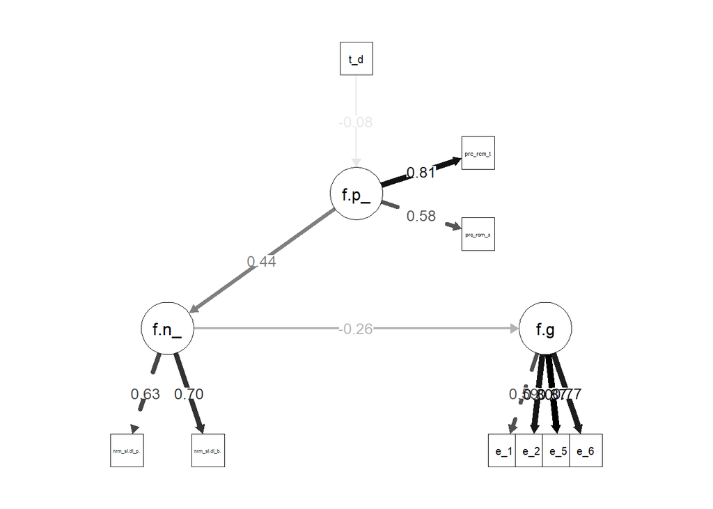

A partir de este analisis se concluye que la meritocracia ejerce un efecto indirecto sifnidicativo sobre considerar la desigualdad como un problema relevante a resolver, por medio de su relacion con la aceptacion de desigualdad de oportunidades. Dicho de otro modo, quienes consiven que el sistema reparte recursos por talento y esfuerzo son mas problives a considerar justas las desigualdes de oportunidades, asi como quienes son mas propenso a considerarlas como justas son igualmente propensos a tener poco interes por la igualdad como un problema. El efecto indirecto es de -.116 desviaciones estandar que disminuye la preocupacion por la igualdad por cada desviacion estandar que aumenta la percepcion de meritocracia.